# STOR 767 Spring 2019 Hw1: Computational Part

Zhenghan Fang

**Instruction.**

**Exercise 1.** *(5 pt)* **Hadamard matrix** is a useful construction for two-level orthogonal design. It’s defined recursively by
$${\mathbf{H}}_1 = \begin{pmatrix} 1 \end{pmatrix} \in {\mathbb{R}}^{1\times 1}, \quad {\mathbf{H}}_{2^k} = \begin{pmatrix} {\mathbf{H}}_{2^{k-1}} & {\mathbf{H}}_{2^{k-1}} \\ {\mathbf{H}}_{2^{k-1}} & - {\mathbf{H}}_{2^{k-1}} \end{pmatrix} \in {\mathbb{R}}^{2^{k}\times 2^{k}}. \quad(k \in {\mathbb{N}})$$
Create ${\mathbf{H}}_{2^4}$ in **R**.

```r
H <- c(1)
for (i in 1:4){
  H <- cbind(rbind(H, H), rbind(H, -H))
}

# print result
H
```

```
##   [,1] [,2] [,3] [,4] [,5] [,6] [,7] [,8] [,9] [,10] [,11] [,12] [,13]
## H    1    1    1    1    1    1    1    1    1     1     1     1     1
## H    1   -1    1   -1    1   -1    1   -1    1    -1     1    -1     1
## H    1    1   -1   -1    1    1   -1   -1    1     1    -1    -1     1
## H    1   -1   -1    1    1   -1   -1    1    1    -1    -1     1     1
## H    1    1    1    1   -1   -1   -1   -1    1     1     1     1    -1
## H    1   -1    1   -1   -1    1   -1    1    1    -1     1    -1    -1
## H    1    1   -1   -1   -1   -1    1    1    1     1    -1    -1    -1
## H    1   -1   -1    1   -1    1    1   -1    1    -1    -1     1    -1
## H    1    1    1    1    1    1    1    1   -1    -1    -1    -1    -1
## H    1   -1    1   -1    1   -1    1   -1   -1     1    -1     1    -1
## H    1    1   -1   -1    1    1   -1   -1   -1    -1     1     1    -1
## H    1   -1   -1    1    1   -1   -1    1   -1     1     1    -1    -1
## H    1    1    1    1   -1   -1   -1   -1   -1    -1    -1    -1     1
## H    1   -1    1   -1   -1    1   -1    1   -1     1    -1     1     1
## H    1    1   -1   -1   -1   -1    1    1   -1    -1     1     1     1
## H    1   -1   -1    1   -1    1    1   -1   -1     1     1    -1     1
##   [,14] [,15] [,16]
## H     1     1     1
## H    -1     1    -1
## H     1    -1    -1
## H    -1    -1     1
## H    -1    -1    -1
## H     1    -1     1
## H    -1     1     1
## H     1     1    -1
## H    -1    -1    -1
## H     1    -1     1
## H    -1     1     1
## H     1     1    -1
## H     1     1     1
## H    -1     1    -1
## H     1    -1    -1
## H    -1    -1     1
```

**Exercise 2.** *(5 pt)* It has been shown that a LASSO estimate for the location of $X$ is of the following thresholding form
$$\hat{\mu}_{\textrm{LASSO}} = {\mathop{\mathrm{argmin}}}_{\mu \in {\mathbb{R}}} {1 \over 2} (X - \mu)^2 + \lambda |\mu| = \begin{cases}
X + \lambda, & X \le -\lambda \\
0, & -\lambda < X \le \lambda \\
X - \lambda, & X > \lambda
\end{cases}$$
Now let $\lambda=1$ and consider 100 *i.i.d.* sample $\{X_i\}_{i=1}^n$ drawn from ${\mathcal{N}}(0,1)$. Return the vector of the LASSO estimates for their individual locations in **R**.

```r
x <- rnorm(100)
u <- x
u[x <= -1] <- x[x <= -1] + 1
u[x > -1 & x <= 1] <- 0
u[x >= 1] <- x[x >= 1] - 1

# print result
x
```

```
##   [1]  0.5943865703  3.3087103554  0.9323227078  0.0556980487 -1.2264515865
##   [6] -1.3868332706  0.2038965745  0.0343313804  0.9930183997  1.6052318065
##  [11]  1.0257664920  0.5422505858 -1.2575793937 -0.6928926334  0.4760959161
##  [16] -1.0063116022  1.7435642538  1.2819569468  0.8979805928  0.8621700438
##  [21] -0.0981559415  0.5355018064  0.1916791117  0.9662878939 -0.1058472596
##  [26]  0.7107075489  0.7353837765  1.2365837032  0.2895714459 -0.9434233852
##  [31] -1.4862103605  0.8256467825 -0.8550072295  0.4500122447 -0.1108345219
##  [36]  2.2032670202 -0.1854006578  0.7906126615  1.3503273265  0.1968681018
##  [41]  0.3988475541 -1.4423449913 -0.9470632369 -1.1497577555  0.3687301421
##  [46] -1.3410044850 -0.6879278790 -2.2773297194 -0.4731754782 -0.0490286102
##  [51]  1.1210784573 -0.4986404378  2.0951877545  2.4596229368  1.8931452054
##  [56]  0.7963787347 -2.0806085258 -0.7419045111  0.9739504292  0.7857172496
##  [61] -0.0265494032 -0.4649173832 -0.1476225189  0.9059029297 -2.1834489708
##  [66] -1.3270690619  0.8574307814  0.6854442953 -1.4993148779 -0.6722954259
##  [71]  1.5802797513  0.0000708472 -1.1137713552  0.1488574690 -2.0421192157
##  [76] -1.0823340059 -0.0308781467 -0.9095978551 -0.4891489553 -0.2078732077
##  [81]  0.3149925806 -1.1316344040  1.0968212034 -1.1042855820 -0.7297797419
##  [86]  1.0154281529 -0.0193838388 -0.0275718792  0.9936115034 -0.3977047997
##  [91]  0.7743222563 -1.6687348777  0.4677997403 -0.5165746805  1.2366116777
##  [96] -1.7489836237 -0.4118675283 -2.4249919274  0.3761312916  0.2448195700
```

```r
u
```

```
##   [1]  0.000000000  2.308710355  0.000000000  0.000000000 -0.226451586
##   [6] -0.386833271  0.000000000  0.000000000  0.000000000  0.605231807
##  [11]  0.025766492  0.000000000 -0.257579394  0.000000000  0.000000000
##  [16] -0.006311602  0.743564254  0.281956947  0.000000000  0.000000000
##  [21]  0.000000000  0.000000000  0.000000000  0.000000000  0.000000000
##  [26]  0.000000000  0.000000000  0.236583703  0.000000000  0.000000000
##  [31] -0.486210360  0.000000000  0.000000000  0.000000000  0.000000000
##  [36]  1.203267020  0.000000000  0.000000000  0.350327327  0.000000000
##  [41]  0.000000000 -0.442344991  0.000000000 -0.149757755  0.000000000
##  [46] -0.341004485  0.000000000 -1.277329719  0.000000000  0.000000000
##  [51]  0.121078457  0.000000000  1.095187755  1.459622937  0.893145205
##  [56]  0.000000000 -1.080608526  0.000000000  0.000000000  0.000000000
##  [61]  0.000000000  0.000000000  0.000000000  0.000000000 -1.183448971
##  [66] -0.327069062  0.000000000  0.000000000 -0.499314878  0.000000000
##  [71]  0.580279751  0.000000000 -0.113771355  0.000000000 -1.042119216
##  [76] -0.082334006  0.000000000  0.000000000  0.000000000  0.000000000
##  [81]  0.000000000 -0.131634404  0.096821203 -0.104285582  0.000000000
##  [86]  0.015428153  0.000000000  0.000000000  0.000000000  0.000000000
##  [91]  0.000000000 -0.668734878  0.000000000  0.000000000  0.236611678
##  [96] -0.748983624  0.000000000 -1.424991927  0.000000000  0.000000000
```

**Exercise 3.** *(5 pt)* Table presents a mixed 2-level and 3-level orthogonal design from (Wu and Hamada 2011). The first four rows in 2-level factors A, B and C, as a $2^{3-1}$ design, have been repeated for the next eight 4-row groups. Groups are embedded into a $3^{3-1}$ design in 3-level factors D, E and F. In particular, column C = column A $\times$ column B, column F = column D + column E (mod 3) by encoding $(-1,0,1)$ in $(1,2,0)$. Create such design matrix in **R** without reading from Table directly.

```r
A <- rep(c(-1,1), 18)
B <- rep(c(-1,1), each = 2)
B <- rep(B, 9)
C <- A * B
D <- rep(c(-1, 0, 1), each = 4)
D <- rep(D, 3)
E <- rep(c(-1, 0, 1), each = 12)
F <- ((D + 2) %% 3 + (E + 2) %% 3) %% 3
F <- ((F + 1) %% 3) - 1

A <- factor(A)
B <- factor(B)
C <- factor(C)
D <- factor(D)
E <- factor(E)
F <- factor(F)
orth_arr <- data.frame(A, B, C, D, E, F)

# print result
orth_arr
```

```
##     A  B  C  D  E  F
## 1  -1 -1  1 -1 -1 -1
## 2   1 -1 -1 -1 -1 -1
## 3  -1  1 -1 -1 -1 -1
## 4   1  1  1 -1 -1 -1
## 5  -1 -1  1  0 -1  0
## 6   1 -1 -1  0 -1  0
## 7  -1  1 -1  0 -1  0
## 8   1  1  1  0 -1  0
## 9  -1 -1  1  1 -1  1
## 10  1 -1 -1  1 -1  1
## 11 -1  1 -1  1 -1  1
## 12  1  1  1  1 -1  1
## 13 -1 -1  1 -1  0  0
## 14  1 -1 -1 -1  0  0
```

[output cut: 22 more lines]

**Exercise 4.** *(5 pt)* Thickness data from a paint experiment based on Table design in (Wu and Hamada 2011) are collected as below. Compute the sum of squares for all factors (main effects) from scratch, *i.e.* without resorting to any ANOVA-type **R** functions. Compare them with outputs produced by `aov`.

```r
y <- scan(text = "0.755 0.550 0.550 0.600 0.900 0.875 1.000 1.000 1.400 1.225 1.225 1.475
0.600 0.600 0.625 0.500 0.925 1.025 0.875 0.850 1.200 1.250 1.150 1.150 0.500 0.550 0.575
0.600 0.900 1.025 0.850 0.975 1.100 1.200 1.150 1.300")

data.t = cbind(orth_arr, y)
mean.all <- mean(data.t$y)
n.all <- length(data.t$y)
Sum.Sq <- c()
for(i in c("A", "B", "C", "D", "E", "F")){
  mean.group <- tapply(data.t$y, data.t[[i]], mean)
  n.group <- tapply(rep(1, n.all), data.t[[i]], sum)
  Sum.Sq[i] <- sum(n.group * (mean.group - mean.all) ^ 2)
}

data.t.aov.A <- aov(y ~ A, data.t)
data.t.aov.B <- aov(y ~ B, data.t)
data.t.aov.C <- aov(y ~ C, data.t)
data.t.aov.D <- aov(y ~ D, data.t)
data.t.aov.E <- aov(y ~ E, data.t)
data.t.aov.F <- aov(y ~ F, data.t)

# print results
Sum.Sq
```

```
##            A            B            C            D            E
## 0.0061361111 0.0004694444 0.0051361111 2.5525291667 0.0371541667
##            F
## 0.0062375000
```

```r
summary(data.t.aov.A)
```

```
##             Df Sum Sq Mean Sq F value Pr(>F)
## A            1 0.0061 0.00614   0.075  0.786
## Residuals   34 2.7782 0.08171
```

```r
summary(data.t.aov.B)
```

```
##             Df Sum Sq Mean Sq F value Pr(>F)
## B            1 0.0005 0.00047   0.006   0.94
## Residuals   34 2.7839 0.08188
```

```r
summary(data.t.aov.C)
```

```
##             Df Sum Sq Mean Sq F value Pr(>F)
## C            1 0.0051 0.00514   0.063  0.804
## Residuals   34 2.7792 0.08174
```

```r
summary(data.t.aov.D)
```

```
##             Df Sum Sq Mean Sq F value Pr(>F)
## D            2 2.5525   1.276   181.7 <2e-16 ***
## Residuals   33 0.2318   0.007
## ---
## Signif. codes:  0 '***' 0.001 '**' 0.01 '*' 0.05 '.' 0.1 ' ' 1
```

```r
summary(data.t.aov.E)
```

```
##             Df Sum Sq Mean Sq F value Pr(>F)
## E            2 0.0372 0.01858   0.223  0.801
## Residuals   33 2.7472 0.08325
```

```r
summary(data.t.aov.F)
```

```
##             Df Sum Sq Mean Sq F value Pr(>F)
## F            2 0.0062 0.00312   0.037  0.964
## Residuals   33 2.7781 0.08419
```

**Exercise 5.** *(10 pt)* Write a function `optim_gd(par, fn, gr, gr_lips, maxit = 10000, tol = 1e-5)` to find the minimizer of a smooth convex function using gradient descent.[^1]

- `par`: initial values for the parameters to be optimized over.
- `fn`: objective function to be minimized $f$ on domain ${\mathcal{X}}$.
- `gr`: gradient of objective function $\nabla f$.
- `gr_lips`: Lipschitz gradient constant $L_f$, *i.e.*
  $$\|\nabla f({\bm{x}}) - \nabla f({\bm{y}})\|_2 \le L_f\|{\bm{x}}- {\bm{y}}\|_2. \quad (\forall {\bm{x}}, {\bm{y}}\in {\mathcal{X}})$$
- `maxit`: maximal number of iterations.
- `tol`: convergence tolerance parameter $\epsilon > 0$.

Iterations are performed by
$${\bm{x}}^{k+1} := {\bm{x}}^k - {1 \over L_f}\nabla f({\bm{x}}^k)$$
with stopping criterion
$${\|\nabla f({\bm{x}}^k)\|_2 \over \max\{1,\|\nabla f({\bm{x}}^0)\|_2\}} \le \epsilon.$$

Return a list with `par =` minimizer, `value =` optimal objective value, and `counts =` number of iterations performed. Apply it to the bivariate function[^2]

$$f(x_1,x_2) = \log\left( 1+e^{-x_1+x_2} \right) + \log\left( 1+e^{x_1} \right) + \log\left( 1+e^{-x_1-x_2} \right)$$
with $L_f = {5 \over 4}$ and initial value $(0, 0)$. Compare it with the built-in optimization function `optim` with `method = "BFGS"`.

```r
fn.biv <- function(x){
  x1 <- x[1]
  x2 <- x[2]
  log(1 + exp(- x1 + x2)) + log(1 + exp(x1)) + log(1 + exp(- x1 - x2))
}

gr.biv <- function(x){
  x1 <- x[1]
  x2 <- x[2]
  gr.x1 <- - exp(- x1 + x2) / (1 + exp(- x1 + x2)) + exp(x1) / (1 + exp(x1)) - exp(- x1 - x2) / (1 + exp(- x1 - x2))
  gr.x2 <- exp(- x1 + x2) / (1 + exp(- x1 + x2)) - exp(- x1 - x2) / (1 + exp(- x1 - x2))
  return(c(gr.x1, gr.x2))
}

optim_gd <- function(par, fn, gr, gr_lips, maxit = 10000, tol = 1e-5){
  gr_0 <- gr(par)
  for(i in 1:maxit){
    gr_i <- gr(par)
    if(sum(gr_i^2) / max(1, sum(gr_0^2)) <= tol) break
    par <- par - gr_i / gr_lips
  }
  list( par = par,
        value = fn(par),
        counts = i - 1)
}

optim_gd(c(0, 0), fn.biv, gr.biv, 5/4)
```

```
## $par
## [1] 0.6903931 0.0000000
##
## $value
## [1] 1.909545
##
## $counts
## [1] 7
```

```r
optim(c(0, 0), fn.biv, method = "BFGS")
```

```
## $par
## [1]  6.931472e-01 -5.514553e-14
##
## $value
## [1] 1.909543
##
## $counts
## function gradient
##       18        5
##
## $convergence
## [1] 0
##
## $message
## NULL
```

```r
data.t = cbind(orth_arr, y = y)
mean.all <- mean(data.t$y)
n.all <- length(data.t$y)
SSb <- c()
dfb <- c()
MSb <- c()
SSw <- c()
dfw <- c()
MSw <- c()
F.aov <- c()
Pr <- c()
signif.indicator <- c()

for(i in c("A", "B", "C", "D", "E", "F")){
  mean.group <- tapply(data.t$y, data.t[[i]], mean)
  n.group <- tapply(rep(1, n.all), data.t[[i]], sum)
  SSb[i] <- sum(n.group * (mean.group - mean.all) ^ 2)

  dfb[i] <- length(levels(data.t[[i]])) - 1

  MSb[i] <- SSb[i] / dfb[i]

  mean.group.long <- data.t$y
  for(j in levels(data.t[[i]])){
    mean.group.long[data.t[[i]] == j] <- mean.group[j]
  }

  SSw[i] <- sum( (data.t$y - mean.group.long) ^ 2 )
  dfw[i] <- n.all - length(levels(data.t[[i]]))
  MSw[i] <- SSw[i] / dfw[i]

  F.aov[i] <- MSb[i] / MSw[i]

  Pr[i] <- 1 - pf( F.aov[i], dfb[i], dfw[i] )

  if(Pr[i] <= 0.001)
    sig <- "***"
  else if(Pr[i] <= 0.01)
    sig <- "**"
  else if(Pr[i] <= 0.05)
    sig <- "*"
  else if(Pr[i] <= 0.1)
    sig <- "."
  else
    sig <- " "

  signif.indicator[i] <- sig

}

my.aov.table <- data.frame(Sum_Sq = SSb,
                           Df = dfb,
                           F_value = F.aov,
                           p_value = Pr,
                           Signif = signif.indicator)

# print results
my.aov.table
```

```
##         Sum_Sq Df      F_value   p_value Signif
## A 0.0061361111  1 7.509353e-02 0.7857181
## B 0.0004694444  1 5.733352e-03 0.9400865
## C 0.0051361111  1 6.283295e-02 0.8035817
## D 2.5525291667  2 1.816583e+02 0.0000000    ***
## E 0.0371541667  2 2.231505e-01 0.8011917
## F 0.0062375000  2 3.704595e-02 0.9636719
```

```r
summary(data.t.aov.A)
```

```
##             Df Sum Sq Mean Sq F value Pr(>F)
## A            1 0.0061 0.00614   0.075  0.786
## Residuals   34 2.7782 0.08171
```

```r
summary(data.t.aov.B)
```

```
##             Df Sum Sq Mean Sq F value Pr(>F)
## B            1 0.0005 0.00047   0.006   0.94
## Residuals   34 2.7839 0.08188
```

```r
summary(data.t.aov.C)
```

```
##             Df Sum Sq Mean Sq F value Pr(>F)
## C            1 0.0051 0.00514   0.063  0.804
## Residuals   34 2.7792 0.08174
```

```r
summary(data.t.aov.D)
```

```
##             Df Sum Sq Mean Sq F value Pr(>F)
## D            2 2.5525   1.276   181.7 <2e-16 ***
## Residuals   33 0.2318   0.007
## ---
## Signif. codes:  0 '***' 0.001 '**' 0.01 '*' 0.05 '.' 0.1 ' ' 1
```

```r
summary(data.t.aov.E)
```

```
##             Df Sum Sq Mean Sq F value Pr(>F)
## E            2 0.0372 0.01858   0.223  0.801
## Residuals   33 2.7472 0.08325
```

```r
summary(data.t.aov.F)
```

```
##             Df Sum Sq Mean Sq F value Pr(>F)
## F            2 0.0062 0.00312   0.037  0.964
## Residuals   33 2.7781 0.08419
```

**Exercise 7.** *(10 pt)* Reproduce the code that generates the following plot based on **Exercise 4**.

[figure not shown]

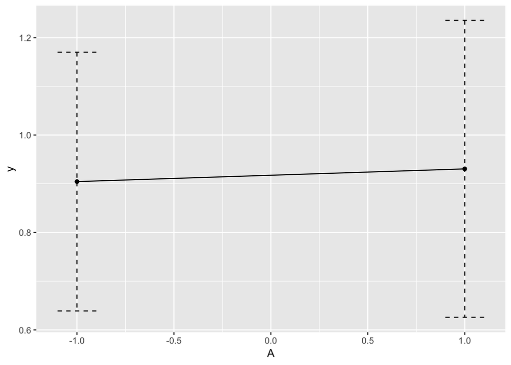

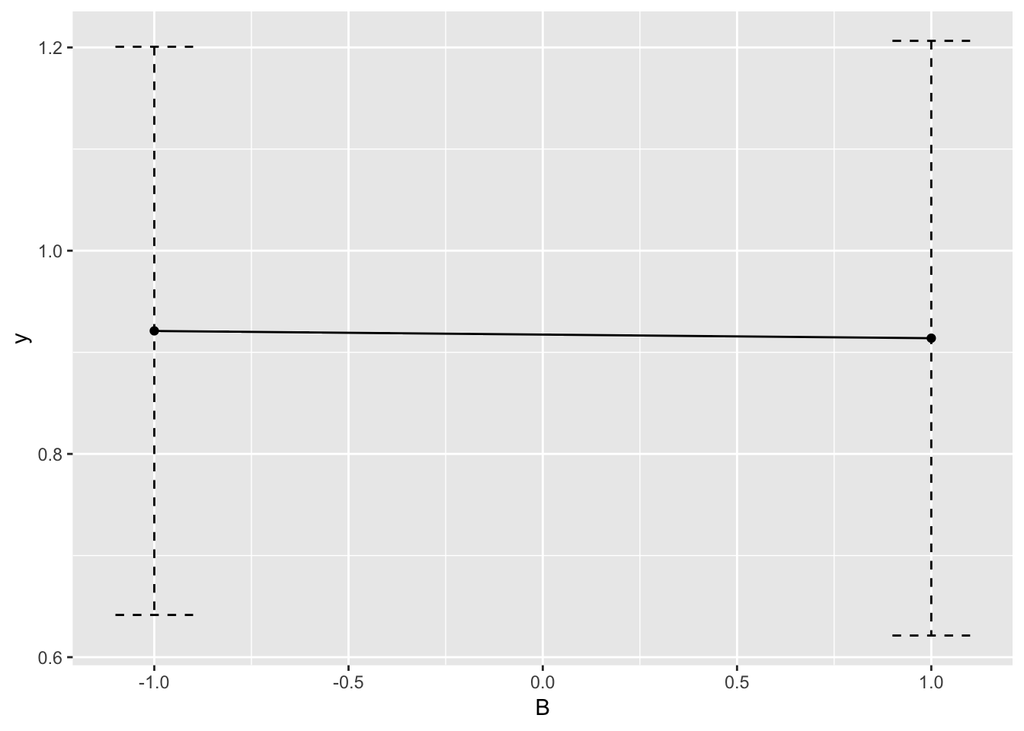

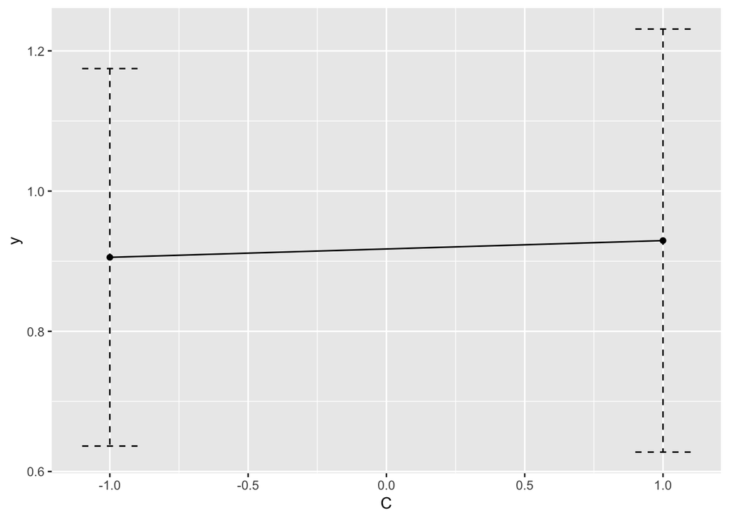

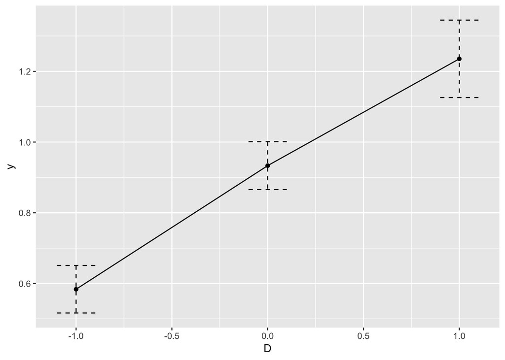

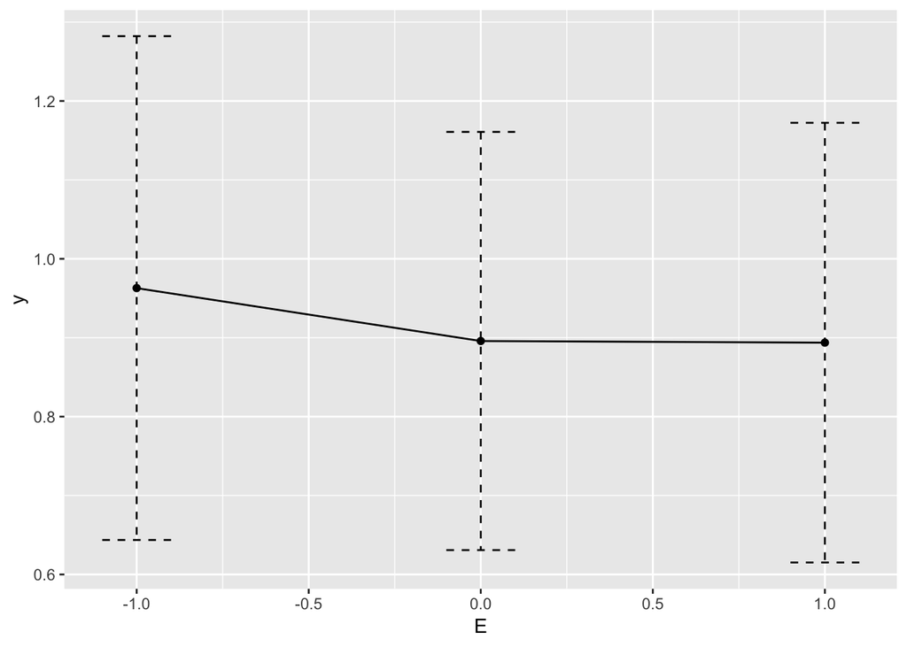

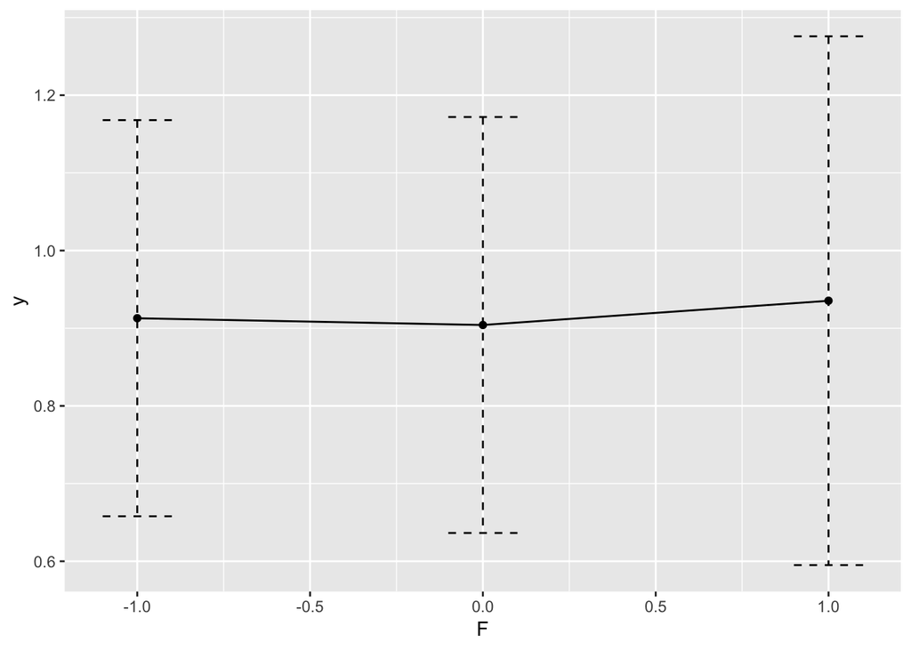

```r
for(i in c("A", "B", "C", "D", "E", "F")){
  mean.group <- tapply(data.t$y, data.t[[i]], mean)
  var.group <- tapply(data.t$y, data.t[[i]], var)
  plot.data <- data.frame(fac = as.numeric(levels(data.t[[i]])),
             mean = mean.group,
             sd = sqrt(var.group) )
  fig <- ggplot(plot.data, aes(x=fac, y=mean)) +
    geom_line(linetype = 1) +
    geom_errorbar(aes(ymin=mean-sd, ymax=mean+sd), width=.2, linetype = 2) +
    geom_point() +
    xlab(i) +
    ylab("y")
  print(fig)
}
```

# Biblography

Wu, C.F. Jeff, and Michael S. Hamada. 2011. *Experiments: Planning, Analysis, and Optimization*. Vol. 552. John Wiley & Sons.

[^1]: STOR 893 Fall 2018 lecture note http://quoctd.web.unc.edu/files/2018/10/lecture4-selected-cvx-methods.pdf.
[^2]: Negative log-likelihood of Logistic regression of the data $\{(-1,1),(0,0),(1,1)\}$. Try performing `glm` to see whether the outputs coincide.